# SLX Contra Simple Regression

Upon investigating model performance with train/validate splits for the 2019 and 2025 snapshots, ridge and lasso regression models performed well compared to SLX in the poc notebook. Since SLX was only tried on pca with 20 components previously, this new insight warrants returning to SLX for comparison on respective reduction techniques.

Then, this notebook should be informative on the relevance of an SLX model in the face of high performance from simpler regression models.

```python
import json
from itertools import product

import numpy as np
import pandas as pd
import matplotlib.pyplot as plt
import seaborn as sns

from sklearn.metrics import pairwise_distances
from sklearn.decomposition import PCA
from sklearn.preprocessing import StandardScaler
from sklearn.model_selection import GroupKFold

from sklearn.cluster import KMeans
from sklearn.metrics import mean_squared_error, r2_score
import geopandas as gpd
from shapely.geometry import shape

from esda.moran import Moran
from esda.geary import Geary

from sklearn.decomposition import PCA, FactorAnalysis
from sklearn.preprocessing import StandardScaler
from sklearn.model_selection import cross_val_score, GridSearchCV
from sklearn.linear_model import Ridge, Lasso, ElasticNet

from scipy.stats import spearmanr, pearsonr

import warnings
warnings.filterwarnings("ignore")

RANDOM_STATE = 19
```

## Setup Features and Target

```python
# Load dataset and imd to create merged dataset with target variable

indicators_2019 = pd.read_parquet('combined_indicators_2019.parquet', engine='fastparquet')
indicators_2025 = pd.read_parquet('combined_indicators_2025.parquet', engine='fastparquet')

scores_2019 = pd.read_csv('imd_2019_scores.csv')
scores_2025 = pd.read_csv('imd_2025_scores.csv')

lsoa_lookup = pd.read_csv('lsoa_2011_2021_lookup.csv')
```

### Perform Joins

```python
scores_2019.rename(columns={'LSOA code (2011)': 'lsoa_code_11',
                           'Index of Multiple Deprivation (IMD) Score': 'imd_score'
                          }, inplace=True)

# lsoa codes were changed in 2021, so 2019 codes are converted to 2021 codes using the lookup table
scores_2019 = scores_2019.merge(lsoa_lookup[['lsoa_code_11', 'lsoa_code_21']], on='lsoa_code_11', how='right')
scores_2019.drop(columns=['lsoa_code_11'], inplace=True)
scores_2019.rename(columns={'lsoa_code_21': 'lsoa_code'}, inplace=True)


scores_2025.rename(columns={'LSOA code (2021)': 'lsoa_code',
                           'Index of Multiple Deprivation (IMD) Score': 'imd_score'
                          }, inplace=True)

scores_2019 = scores_2019[['lsoa_code', 'imd_score']]
scores_2025 = scores_2025[['lsoa_code', 'imd_score']]

# Merge features and target datasets on 'lsoa_code'
data_2019 = pd.merge(indicators_2019, scores_2019, on='lsoa_code')
data_2025 = pd.merge(indicators_2025, scores_2025, on='lsoa_code', how='left')
```

```python
# Ensure features are consistent between datasets
common_features = list(set(data_2019.columns).intersection(set(data_2025.columns)))
data_2019 = data_2019[common_features]
data_2025 = data_2025[common_features]
```

```python
# Check that now datasets have the same shape
data_2019.shape == data_2025.shape
```

```
True
```

### NaN, Null and Inf Values

```python
if np.isinf(data_2019.select_dtypes(include=['number'])).sum().sum()>0:
    print("Warning: Infinite values found in 2019 dataset, replaced with NaN.")
    data_2019.replace([np.inf, -np.inf], np.nan, inplace=True)

if np.isinf(data_2025.select_dtypes(include=['number'])).sum().sum()>0:
    print("Warning: Infinite values found in 2025 dataset.")
    data_2025.replace([np.inf, -np.inf], np.nan, inplace=True)
```

```python
# 2019

missingness = data_2019.isna().sum().sort_values(ascending=False)
missingness_percent = (missingness / len(data_2019)) * 100
missingness_df_2019 = pd.DataFrame({
    'feature': missingness.index,
    'missing_count': missingness.values,
    'missing_percent': missingness_percent.values
})

data_2019 = data_2019.drop(columns=missingness_df_2019[missingness_df_2019['missing_percent'] > 20]['feature'])
data_2019 = data_2019.fillna(data_2019.median(numeric_only=True))

missingness_df_2019.sort_values('missing_percent', ascending=False).head(10)
```

|  | feature | missing_count | missing_percent |
| --- | --- | --- | --- |
| 0 | resolution_rate | 268 | 100.000000 |
| 1 | ratio_fast_food_takeaway_to_food_dining_500 | 36 | 13.432836 |
| 2 | ratio_sustainable_transport_to_transport_car_1000 | 27 | 10.074627 |
| 3 | ratio_alcohol_gambling_to_financial_services_500 | 22 | 8.208955 |
| 4 | ratio_fast_food_takeaway_to_healthcare_access_... | 22 | 8.208955 |
| 5 | Under investigation | 9 | 3.358209 |
| 6 | bicycle-theft | 9 | 3.358209 |
| 7 | Further action is not in the public interest | 9 | 3.358209 |
| 8 | Status update unavailable | 9 | 3.358209 |
| 9 | shoplifting | 9 | 3.358209 |

```python
# 2025

missingness = data_2025.isna().sum().sort_values(ascending=False)
missingness_percent = (missingness / len(data_2025)) * 100
missingness_2025_df = pd.DataFrame({
    'feature': missingness.index,
    'missing_count': missingness.values,
    'missing_percent': missingness_percent.values
})

data_2025 = data_2025.drop(columns=missingness_2025_df[missingness_2025_df['missing_percent'] > 20]['feature'])
data_2025 = data_2025.fillna(data_2025.median(numeric_only=True))

missingness_2025_df.sort_values('missing_percent', ascending=False).head(10)
```

|  | feature | missing_count | missing_percent |
| --- | --- | --- | --- |
| 0 | ratio_cultural_entertainment_to_fast_food_take... | 0 | 0.0 |
| 1 | count_essential_services_2000 | 0 | 0.0 |
| 2 | drugs | 0 | 0.0 |
| 3 | count_essential_services_5000 | 0 | 0.0 |
| 4 | nearest_pharmacy | 0 | 0.0 |
| 5 | count_fast_food_takeaway_500 | 0 | 0.0 |
| 6 | count_elderly_care_0 | 0 | 0.0 |
| 7 | count_transport_car_1500 | 0 | 0.0 |
| 8 | count_public_services_civic_2000 | 0 | 0.0 |
| 9 | landuse_grass_0 | 0 | 0.0 |

```python
# Ensure datasets still have the same shape after dropping features with high missingness
consistent_shape = data_2019.shape == data_2025.shape

print(f"Datasets have consistent shapes: {consistent_shape}")

if not consistent_shape:
    # redo the common features step to ensure both datasets have the same features after dropping those with high missingness
    common_features = list(set(data_2019.columns).intersection(set(data_2025.columns)))
    data_2019 = data_2019[common_features]
    data_2025 = data_2025[common_features]
```

```
Datasets have consistent shapes: False
```

### Define Features and Targets

```python
data_2019.set_index("lsoa_code", inplace=True)
data_2025.set_index("lsoa_code", inplace=True)

X_2019 = data_2019.drop(columns=['imd_score']).values
y_2019 = data_2019['imd_score'].values

X_2025 = data_2025.drop(columns=['imd_score']).values
y_2025 = data_2025['imd_score'].values
```

## Setup GeoSpatial Aspects

### Load Geo Shapes

```python
lsoa_shapes = pd.read_csv("geography_lookup.csv")

# convert geojson string to geometry
lsoa_shapes["geometry"] = lsoa_shapes["geo_shape"].apply(lambda x: shape(json.loads(x)))
lsoa_shapes = lsoa_shapes[["lsoa_code", "geometry"]]

print(lsoa_shapes.head())

# merge modelling data to get full geo-spatial dataset
gdf = gpd.GeoDataFrame(lsoa_shapes, geometry="geometry", crs="EPSG:4326").merge(data_2025, on="lsoa_code", how="left")
```

```
   lsoa_code                                           geometry
0  E01014488  MULTIPOLYGON (((-2.581270401359658 51.47053350...
1  E01014693  MULTIPOLYGON (((-2.581328182358106 51.51617262...
2  E01033909  MULTIPOLYGON (((-2.598659490202402 51.45494441...
3  E01033903  MULTIPOLYGON (((-2.584357699648935 51.45285959...
4  E01032514  MULTIPOLYGON (((-2.59432877773493 51.409612444...
```

### Get Distance Matrix

```python
# Get centroid coordinates for distance matrix
coords = np.array(list(zip(gdf.geometry.centroid.x, gdf.geometry.centroid.y)))

# Compute distance matrix
distances = pairwise_distances(coords)

# Create adjacency: neighbors if within some distance threshold
threshold = 0.01  # roughly 700 meters with 1 ~ 111km
w = (distances < threshold).astype(float)

# row-standardize weights
w = w / w.sum(axis=1, keepdims=True)
```

### Get Spatial CV Clusters

```python
# Setup for spatial cross validation

centroids = np.array(list(zip(gdf.geometry.centroid.x, gdf.geometry.centroid.y)))
n_clusters = 10
kmeans = KMeans(n_clusters=n_clusters, random_state=RANDOM_STATE).fit(centroids)
gdf["cluster_id"] = kmeans.labels_

groups = gdf["cluster_id"].values
```

## Modelling

### Define Spatial CV, Reductions and Eval Params

```python
initial_feature_sets = {
    'pca_100': 100,
    'pca_75' : 75,
    'pca_50': 50,
    'pca_20': 20,
    'pca_10': 10,
    'pca_5': 5,
    'fa_100': 100,
    'fa_75' : 75,
    'fa_50': 50,
    'fa_20': 20,
    'fa_10': 10,
    'fa_5': 5,
    'scaled': None,
    'none': None,
}

ridge_params = [0.1, 1.0, 10.0, 20.0, 50.0, 80.0, 100.0] # chosen using knowledge from 19/25 experiments
lasso_params = [0.001, 0.01, 0.1, 1] # chosen as base


gkf = GroupKFold(n_splits=5)
```

### Perform CV

```python
def evaluate_models(
        feature_sets: dict = {'scaled': None},
        alphas: list = [0.01, 0.1, 1, 10, 100],
        elnet_ratio: list = [0.2, 0.5, 0.8],
        models: list = ['Ridge', 'SLX_Ridge'],
        feature_names: list | None = None
):

    results_row = []
    coefs_list = []

    for direction in ['2019 -> 2025', '2025 -> 2019']:

        if direction == '2019 -> 2025':
            X_cv = X_2019
            y_cv = y_2019
            X_val = X_2025
            y_val = y_2025
        else:
            X_cv = X_2025
            y_cv = y_2025
            X_val = X_2019
            y_val = y_2019

        for reduction_config in feature_sets.keys():
            n = feature_sets[reduction_config]

            for model_type in models:
                if model_type not in ['Ridge', 'Lasso', 'Elastic_Net', 'SLX_Ridge', 'SLX_Lasso', 'SLX_Elastic_Net']:
                    continue

                if model_type not in ['Elastic_Net', 'SLX_Elastic_Net']:
                    elnet_ratio = [0]

                for a, lr_ratio  in product(alphas, elnet_ratio):

                    r2_scores = []
                    rmse_scores = []
                    spearmensr_scores = []
                    coeffs_cv = []

                    # CV loop
                    for train_idx, test_idx in gkf.split(X_cv, y_cv, groups=groups):

                        # Train/test split
                        X_train_raw, X_test_raw = X_cv[train_idx], X_cv[test_idx]
                        y_train, y_test = y_cv[train_idx], y_cv[test_idx]

                        scaler = StandardScaler()
                        X_train_scaled = scaler.fit_transform(X_train_raw)
                        X_test_scaled = scaler.transform(X_test_raw)

                        # Dimension reduction
                        if 'pca' in reduction_config:
                            pca = PCA(n_components=n)
                            X_train = pca.fit_transform(X_train_scaled)
                            X_test = pca.transform(X_test_scaled)
                            # Name features as PCA1, PCA2, ...
                            feature_names_curr = [f"PCA_{i+1}" for i in range(n)]
                        elif 'fa' in reduction_config:
                            fa = FactorAnalysis(n_components=n)
                            X_train = fa.fit_transform(X_train_scaled)
                            X_test = fa.transform(X_test_scaled)
                            feature_names_curr = [f"FA_{i+1}" for i in range(n)]
                        elif 'scaled' in reduction_config:
                            X_train = X_train_scaled
                            X_test = X_test_scaled
                            feature_names_curr = list(data_2019.drop(columns='imd_score').columns)
                        else:
                            X_train = X_train_raw
                            X_test = X_test_raw
                            feature_names_curr = feature_names if feature_names is not None else [f"X{i}" for i in range(X_train.shape[1])]

                        # Spatial features
                        WX_train = w[np.ix_(train_idx, train_idx)] @ X_train
                        WX_test  = w[np.ix_(test_idx, train_idx)]  @ X_train
                        X_train_slx = np.hstack([X_train, WX_train])
                        X_test_slx = np.hstack([X_test, WX_test])
                        if 'SLX' in model_type:
                            feature_names_curr = feature_names_curr + [f"W_{name}" for name in feature_names_curr]

                        # Model selection
                        if model_type == 'Ridge':
                            model = Ridge(alpha=a)
                            X_tr, X_te = X_train, X_test
                        elif model_type == 'Lasso':
                            model = Lasso(alpha=a, max_iter=10000, random_state=RANDOM_STATE)
                            X_tr, X_te = X_train, X_test
                        elif model_type == 'Elastic_Net':
                            model = ElasticNet(alpha=a, l1_ratio=lr_ratio, max_iter=10000, random_state=RANDOM_STATE)
                            X_tr, X_te = X_train, X_test
                        elif model_type == 'SLX_Ridge':
                            model = Ridge(alpha=a)
                            X_tr, X_te = X_train_slx, X_test_slx
                        elif model_type == 'SLX_Lasso':
                            model = Lasso(alpha=a, max_iter=10000, random_state=RANDOM_STATE)
                            X_tr, X_te = X_train_slx, X_test_slx
                        elif model_type == 'SLX_Elastic_Net':
                            model = ElasticNet(alpha=a, l1_ratio=lr_ratio, max_iter=10000, random_state=RANDOM_STATE)
                            X_tr, X_te = X_train_slx, X_test_slx

                        # Fit and predict
                        model.fit(X_tr, y_train)
                        y_pred = model.predict(X_te)

                        r2_scores.append(r2_score(y_test, y_pred))
                        rmse_scores.append(np.sqrt(mean_squared_error(y_test, y_pred)))
                        spearmens_score, _ = spearmanr(y_test, y_pred)
                        spearmensr_scores.append(spearmens_score)
                        coeffs_cv.append(model.coef_)

                    # Validation model
                    scaler = StandardScaler()
                    X_cv_scaled = scaler.fit_transform(X_cv)
                    X_val_scaled = scaler.transform(X_val)

                    if 'pca' in reduction_config:
                        pca = PCA(n_components=n)
                        X_cv_red = pca.fit_transform(X_cv_scaled)
                        X_val_red = pca.transform(X_val_scaled)
                    elif 'fa' in reduction_config:
                        fa = FactorAnalysis(n_components=n)
                        X_cv_red = fa.fit_transform(X_cv_scaled)
                        X_val_red = fa.transform(X_val_scaled)
                    else:
                        X_cv_red = X_cv_scaled
                        X_val_red = X_val_scaled

                    if model_type in ['SLX_Ridge', 'SLX_Lasso', 'SLX_Elastic_Net']:
                        WX_cv = w @ X_cv_red
                        X_cv_red = np.hstack([X_cv_red, WX_cv])
                        WX_val = w @ X_val_red
                        X_val_red = np.hstack([X_val_red, WX_val])

                    # Fit validation model
                    val_model = None
                    if model_type in ['Ridge', "SLX_Ridge"]:
                        val_model = Ridge(alpha=a)
                    elif model_type in ['Lasso', "SLX_Lasso"]:
                        val_model = Lasso(alpha=a, max_iter=10000, random_state=RANDOM_STATE)
                    elif model_type in ['Elastic_Net', 'SLX_Elastic_Net']:
                        val_model = ElasticNet(alpha=a, l1_ratio=lr_ratio, max_iter=10000, random_state=RANDOM_STATE)



                    val_model.fit(X_cv_red, y_cv)
                    val_coef = val_model.coef_

                    # Store results
                    results_row.append(
                        {
                            'feature_set': reduction_config,
                            'model': model_type,
                            'cv_rmse_std': np.std(rmse_scores),
                            'cv_rmse_mean': np.mean(rmse_scores),
                            'cv_r2_std': np.std(r2_scores),
                            'cv_r2_mean': np.mean(r2_scores),
                            'cv_spearmensr_std':np.std(spearmensr_scores),
                            'cv_spearmensr_mean': np.mean(spearmensr_scores),
                            'val_r2': r2_score(y_val, val_model.predict(X_val_red)),
                            'spearmensr': spearmanr(y_val, val_model.predict(X_val_red))[0],
                            'alpha': a,
                            'lr_ratio': lr_ratio,
                            'direction': direction,
                        }
                    )

                    # Build coefficient DataFrame rows with feature names
                    coeffs_cv_arr = np.array(coeffs_cv)
                    for idx, fname in enumerate(feature_names_curr):
                        coefs_list.append({
                            'feature_name': fname,
                            'validation_value': val_coef[idx],
                            'cv_mean': coeffs_cv_arr[:, idx].mean(),
                            'cv_spread': coeffs_cv_arr[:, idx].std(),
                            'model': model_type,
                            'alpha': a,
                            'feature_set': reduction_config,
                            'direction': direction
                        })

    results_df = pd.DataFrame(results_row)
    coefs_df = pd.DataFrame(coefs_list).set_index('feature_name')
    return results_df, coefs_df
```

```python
results_df, coefs_df = evaluate_models(
    feature_sets=initial_feature_sets,
    models=[
        'Ridge',
        'SLX_Ridge',
        'Lasso',
        'SLX_Lasso',
        'SLX_Elastic_Net',
        "Elastic_Net"
    ]
)
```

## Evaluate

First the results dataframe is checked to see the models which scored highest on spearmensr and r squared on the validation set and during cv.

```python
results_df.sort_values(by='spearmensr', ascending=False).head(10)
```

|  | feature_set | model | cv_rmse_std | cv_rmse_mean | cv_r2_std | cv_r2_mean | cv_spearmensr_std | cv_spearmensr_mean | val_r2 | spearmensr | alpha | lr_ratio | direction |
| --- | --- | --- | --- | --- | --- | --- | --- | --- | --- | --- | --- | --- | --- |
| 372 | scaled | Lasso | 1.553187 | 6.249293 | 0.065353 | 0.846951 | 0.014203 | 0.943354 | 0.702618 | 0.959504 | 1.0 | 0 | 2019 -> 2025 |
| 407 | none | SLX_Lasso | 2.684230 | 8.826271 | 0.179957 | 0.683384 | 0.039582 | 0.889059 | 0.702618 | 0.959504 | 1.0 | 0 | 2019 -> 2025 |
| 402 | none | Lasso | 2.223591 | 7.713855 | 0.113199 | 0.765390 | 0.029022 | 0.906240 | 0.702618 | 0.959504 | 1.0 | 0 | 2019 -> 2025 |
| 377 | scaled | SLX_Lasso | 1.553187 | 6.249293 | 0.065353 | 0.846951 | 0.014203 | 0.943354 | 0.702618 | 0.959504 | 1.0 | 0 | 2019 -> 2025 |
| 192 | fa_100 | Lasso | 1.193018 | 7.123976 | 0.064702 | 0.801071 | 0.011598 | 0.928283 | 0.711713 | 0.953300 | 1.0 | 0 | 2019 -> 2025 |
| 197 | fa_100 | SLX_Lasso | 1.193018 | 7.123976 | 0.064702 | 0.801071 | 0.011598 | 0.928283 | 0.711713 | 0.953300 | 1.0 | 0 | 2019 -> 2025 |
| 222 | fa_75 | Lasso | 1.210866 | 7.174921 | 0.064742 | 0.798513 | 0.011186 | 0.925526 | 0.748352 | 0.952546 | 1.0 | 0 | 2019 -> 2025 |
| 227 | fa_75 | SLX_Lasso | 1.210866 | 7.174921 | 0.064742 | 0.798513 | 0.011186 | 0.925526 | 0.748352 | 0.952546 | 1.0 | 0 | 2019 -> 2025 |
| 376 | scaled | SLX_Lasso | 1.906692 | 5.936801 | 0.096680 | 0.854443 | 0.009075 | 0.942621 | 0.605887 | 0.951765 | 0.1 | 0 | 2019 -> 2025 |
| 406 | none | SLX_Lasso | 3.304135 | 10.820496 | 0.189338 | 0.550225 | 0.042500 | 0.855373 | 0.605887 | 0.951765 | 0.1 | 0 | 2019 -> 2025 |

```python
results_df.sort_values(by='val_r2', ascending=False).head(10)
```

|  | feature_set | model | cv_rmse_std | cv_rmse_mean | cv_r2_std | cv_r2_mean | cv_spearmensr_std | cv_spearmensr_mean | val_r2 | spearmensr | alpha | lr_ratio | direction |
| --- | --- | --- | --- | --- | --- | --- | --- | --- | --- | --- | --- | --- | --- |
| 252 | fa_50 | Lasso | 1.208547 | 7.174303 | 0.064766 | 0.798609 | 0.014172 | 0.930048 | 0.796097 | 0.950387 | 1.0 | 0 | 2019 -> 2025 |
| 257 | fa_50 | SLX_Lasso | 1.208547 | 7.174303 | 0.064766 | 0.798609 | 0.014172 | 0.930048 | 0.796097 | 0.950387 | 1.0 | 0 | 2019 -> 2025 |
| 822 | none | Lasso | 0.498178 | 5.752197 | 0.041821 | 0.860680 | 0.017106 | 0.928914 | 0.768401 | 0.941226 | 1.0 | 0 | 2025 -> 2019 |
| 797 | scaled | SLX_Lasso | 0.278563 | 5.183360 | 0.033513 | 0.887466 | 0.015917 | 0.949202 | 0.768401 | 0.941226 | 1.0 | 0 | 2025 -> 2019 |
| 792 | scaled | Lasso | 0.278564 | 5.183360 | 0.033513 | 0.887466 | 0.015917 | 0.949202 | 0.768401 | 0.941226 | 1.0 | 0 | 2025 -> 2019 |
| 827 | none | SLX_Lasso | 1.064881 | 7.015102 | 0.128421 | 0.777496 | 0.011166 | 0.918718 | 0.768401 | 0.941226 | 1.0 | 0 | 2025 -> 2019 |
| 642 | fa_75 | Lasso | 0.360956 | 6.370678 | 0.037663 | 0.832391 | 0.018712 | 0.934705 | 0.759682 | 0.927287 | 1.0 | 0 | 2025 -> 2019 |
| 647 | fa_75 | SLX_Lasso | 0.360956 | 6.370678 | 0.037663 | 0.832391 | 0.018712 | 0.934705 | 0.759682 | 0.927287 | 1.0 | 0 | 2025 -> 2019 |
| 222 | fa_75 | Lasso | 1.210866 | 7.174921 | 0.064742 | 0.798513 | 0.011186 | 0.925526 | 0.748352 | 0.952546 | 1.0 | 0 | 2019 -> 2025 |
| 227 | fa_75 | SLX_Lasso | 1.210866 | 7.174921 | 0.064742 | 0.798513 | 0.011186 | 0.925526 | 0.748352 | 0.952546 | 1.0 | 0 | 2019 -> 2025 |

```python
results_df.sort_values(by='cv_r2_mean', ascending=False).head(10)
```

|  | feature_set | model | cv_rmse_std | cv_rmse_mean | cv_r2_std | cv_r2_mean | cv_spearmensr_std | cv_spearmensr_mean | val_r2 | spearmensr | alpha | lr_ratio | direction |
| --- | --- | --- | --- | --- | --- | --- | --- | --- | --- | --- | --- | --- | --- |
| 796 | scaled | SLX_Lasso | 0.465009 | 4.714234 | 0.020605 | 0.908261 | 0.012562 | 0.950801 | -1.847608 | 0.479129 | 0.1 | 0 | 2025 -> 2019 |
| 791 | scaled | Lasso | 0.459823 | 4.733439 | 0.021605 | 0.907301 | 0.013528 | 0.950496 | -2.147244 | 0.492141 | 0.1 | 0 | 2025 -> 2019 |
| 797 | scaled | SLX_Lasso | 0.278563 | 5.183360 | 0.033513 | 0.887466 | 0.015917 | 0.949202 | 0.768401 | 0.941226 | 1.0 | 0 | 2025 -> 2019 |
| 792 | scaled | Lasso | 0.278564 | 5.183360 | 0.033513 | 0.887466 | 0.015917 | 0.949202 | 0.768401 | 0.941226 | 1.0 | 0 | 2025 -> 2019 |
| 824 | none | Lasso | 0.521041 | 5.320436 | 0.027981 | 0.883165 | 0.024022 | 0.946081 | -0.056417 | NaN | 100.0 | 0 | 2025 -> 2019 |
| 823 | none | Lasso | 0.694170 | 5.284380 | 0.038613 | 0.881867 | 0.017977 | 0.954215 | 0.392083 | 0.937703 | 10.0 | 0 | 2025 -> 2019 |
| 461 | pca_75 | Lasso | 0.585422 | 5.499908 | 0.019605 | 0.877253 | 0.023940 | 0.923507 | 0.255657 | 0.530286 | 0.1 | 0 | 2025 -> 2019 |
| 633 | fa_75 | Ridge | 0.232780 | 5.509552 | 0.034445 | 0.873055 | 0.024839 | 0.912513 | -0.484394 | 0.727286 | 10.0 | 0 | 2025 -> 2019 |
| 641 | fa_75 | Lasso | 0.387370 | 5.501596 | 0.039529 | 0.872398 | 0.020344 | 0.922629 | 0.328373 | 0.750861 | 0.1 | 0 | 2025 -> 2019 |
| 656 | fa_75 | Elastic_Net | 0.130283 | 5.549823 | 0.031803 | 0.871824 | 0.024973 | 0.912556 | -0.356465 | 0.727821 | 0.1 | 0 | 2025 -> 2019 |

```python
results_df.sort_values(by='cv_spearmensr_mean', ascending=False).head(10)
```

|  | feature_set | model | cv_rmse_std | cv_rmse_mean | cv_r2_std | cv_r2_mean | cv_spearmensr_std | cv_spearmensr_mean | val_r2 | spearmensr | alpha | lr_ratio | direction |
| --- | --- | --- | --- | --- | --- | --- | --- | --- | --- | --- | --- | --- | --- |
| 823 | none | Lasso | 0.694170 | 5.284380 | 0.038613 | 0.881867 | 0.017977 | 0.954215 | 0.392083 | 0.937703 | 10.0 | 0 | 2025 -> 2019 |
| 796 | scaled | SLX_Lasso | 0.465009 | 4.714234 | 0.020605 | 0.908261 | 0.012562 | 0.950801 | -1.847608 | 0.479129 | 0.1 | 0 | 2025 -> 2019 |
| 791 | scaled | Lasso | 0.459823 | 4.733439 | 0.021605 | 0.907301 | 0.013528 | 0.950496 | -2.147244 | 0.492141 | 0.1 | 0 | 2025 -> 2019 |
| 792 | scaled | Lasso | 0.278564 | 5.183360 | 0.033513 | 0.887466 | 0.015917 | 0.949202 | 0.768401 | 0.941226 | 1.0 | 0 | 2025 -> 2019 |
| 797 | scaled | SLX_Lasso | 0.278563 | 5.183360 | 0.033513 | 0.887466 | 0.015917 | 0.949202 | 0.768401 | 0.941226 | 1.0 | 0 | 2025 -> 2019 |
| 828 | none | SLX_Lasso | 1.002067 | 6.271439 | 0.095629 | 0.822681 | 0.020287 | 0.947676 | 0.392083 | 0.937703 | 10.0 | 0 | 2025 -> 2019 |
| 824 | none | Lasso | 0.521041 | 5.320436 | 0.027981 | 0.883165 | 0.024022 | 0.946081 | -0.056417 | NaN | 100.0 | 0 | 2025 -> 2019 |
| 372 | scaled | Lasso | 1.553187 | 6.249293 | 0.065353 | 0.846951 | 0.014203 | 0.943354 | 0.702618 | 0.959504 | 1.0 | 0 | 2019 -> 2025 |
| 377 | scaled | SLX_Lasso | 1.553187 | 6.249293 | 0.065353 | 0.846951 | 0.014203 | 0.943354 | 0.702618 | 0.959504 | 1.0 | 0 | 2019 -> 2025 |
| 376 | scaled | SLX_Lasso | 1.906692 | 5.936801 | 0.096680 | 0.854443 | 0.009075 | 0.942621 | 0.605887 | 0.951765 | 0.1 | 0 | 2019 -> 2025 |

Here it seems Lasso regularisation dominates on metrics will almost all top scoring models being either a Lasso or SLX_Lasso model. Note also that these often happen with just a scaled dataset, likely because of Lassos ability to shrink coefficients to zero and so avoid dimensionality issues by performing feature selection. This is then probably possible because we know from previous experiments that some features correlate heavily with the target variable. Checking weather coefficients chosen is consistent throughout parameters.

However, this on its own is not to say Ridge or Elastic Net did badly, to observe these the result dataframe is queried with these model types specifically.

```python
results_df.query("model != 'Lasso' and model != 'SLX_Lasso'") \
    .sort_values(by="spearmensr", ascending=False) \
    .head(10)
```

|  | feature_set | model | cv_rmse_std | cv_rmse_mean | cv_r2_std | cv_r2_mean | cv_spearmensr_std | cv_spearmensr_mean | val_r2 | spearmensr | alpha | lr_ratio | direction |
| --- | --- | --- | --- | --- | --- | --- | --- | --- | --- | --- | --- | --- | --- |
| 327 | fa_10 | Elastic_Net | 1.175807 | 10.133340 | 0.048448 | 0.607213 | 0.018501 | 0.914310 | 0.459685 | 0.947118 | 1.00 | 0 | 2019 -> 2025 |
| 328 | fa_10 | Elastic_Net | 1.622272 | 15.170391 | 0.029829 | 0.124107 | 0.018624 | 0.914476 | 0.069624 | 0.947091 | 10.00 | 0 | 2019 -> 2025 |
| 329 | fa_10 | Elastic_Net | 1.717238 | 16.268013 | 0.023969 | -0.007080 | 0.018289 | 0.914736 | -0.044946 | 0.947091 | 100.00 | 0 | 2019 -> 2025 |
| 304 | fa_10 | Ridge | 0.890827 | 8.439101 | 0.042314 | 0.726054 | 0.018501 | 0.914310 | 0.540433 | 0.947082 | 100.00 | 0 | 2019 -> 2025 |
| 326 | fa_10 | Elastic_Net | 1.265498 | 7.250824 | 0.078789 | 0.790496 | 0.018489 | 0.914238 | 0.534734 | 0.947047 | 0.10 | 0 | 2019 -> 2025 |
| 303 | fa_10 | Ridge | 1.480484 | 7.160779 | 0.094084 | 0.792429 | 0.018375 | 0.914324 | 0.520798 | 0.947047 | 10.00 | 0 | 2019 -> 2025 |
| 302 | fa_10 | Ridge | 1.685857 | 7.133256 | 0.109046 | 0.790832 | 0.018375 | 0.914324 | 0.509966 | 0.947037 | 1.00 | 0 | 2019 -> 2025 |
| 325 | fa_10 | Elastic_Net | 1.658593 | 7.134754 | 0.107021 | 0.791183 | 0.018375 | 0.914324 | 0.512195 | 0.947037 | 0.01 | 0 | 2019 -> 2025 |
| 300 | fa_10 | Ridge | 1.710204 | 7.132933 | 0.110864 | 0.790463 | 0.018375 | 0.914324 | 0.508605 | 0.947037 | 0.01 | 0 | 2019 -> 2025 |
| 301 | fa_10 | Ridge | 1.707977 | 7.132938 | 0.110697 | 0.790498 | 0.018375 | 0.914324 | 0.508730 | 0.947037 | 0.10 | 0 | 2019 -> 2025 |

```python
results_df.query("model != 'Lasso' and model != 'SLX_Lasso'") \
    .sort_values(by="val_r2", ascending=False) \
    .head(10)
```

|  | feature_set | model | cv_rmse_std | cv_rmse_mean | cv_r2_std | cv_r2_mean | cv_spearmensr_std | cv_spearmensr_mean | val_r2 | spearmensr | alpha | lr_ratio | direction |
| --- | --- | --- | --- | --- | --- | --- | --- | --- | --- | --- | --- | --- | --- |
| 189 | fa_100 | SLX_Ridge | 1.254970 | 8.122181 | 0.038843 | 0.748891 | 0.016041 | 0.913307 | 0.702542 | 0.876088 | 100.00 | 0 | 2019 -> 2025 |
| 746 | fa_10 | Elastic_Net | 2.371584 | 7.747421 | 0.168137 | 0.735877 | 0.117706 | 0.869234 | 0.637979 | 0.805326 | 0.10 | 0 | 2025 -> 2019 |
| 723 | fa_10 | Ridge | 2.473938 | 7.672316 | 0.175880 | 0.738135 | 0.117706 | 0.869234 | 0.631889 | 0.804850 | 10.00 | 0 | 2025 -> 2019 |
| 741 | fa_10 | SLX_Elastic_Net | 2.123980 | 7.807844 | 0.146993 | 0.736771 | 0.126267 | 0.864280 | 0.628282 | 0.785578 | 0.10 | 0 | 2025 -> 2019 |
| 745 | fa_10 | Elastic_Net | 2.543930 | 7.654291 | 0.181569 | 0.737542 | 0.117706 | 0.869234 | 0.627059 | 0.804739 | 0.01 | 0 | 2025 -> 2019 |
| 722 | fa_10 | Ridge | 2.554393 | 7.654343 | 0.182456 | 0.737281 | 0.117706 | 0.869234 | 0.625730 | 0.804657 | 1.00 | 0 | 2025 -> 2019 |
| 728 | fa_10 | SLX_Ridge | 2.204966 | 7.699888 | 0.152599 | 0.741776 | 0.127661 | 0.861565 | 0.625530 | 0.780753 | 10.00 | 0 | 2025 -> 2019 |
| 721 | fa_10 | Ridge | 2.562414 | 7.654995 | 0.183144 | 0.737041 | 0.117706 | 0.869234 | 0.624982 | 0.804657 | 0.10 | 0 | 2025 -> 2019 |
| 720 | fa_10 | Ridge | 2.563215 | 7.655087 | 0.183213 | 0.737016 | 0.117706 | 0.869234 | 0.624905 | 0.804657 | 0.01 | 0 | 2025 -> 2019 |
| 740 | fa_10 | SLX_Elastic_Net | 2.270732 | 7.678188 | 0.157965 | 0.741760 | 0.129581 | 0.859583 | 0.621478 | 0.778893 | 0.01 | 0 | 2025 -> 2019 |

```python
results_df.query("model != 'Lasso' and model != 'SLX_Lasso'") \
    .sort_values(by="cv_r2_mean", ascending=False) \
    .head(10)
```

|  | feature_set | model | cv_rmse_std | cv_rmse_mean | cv_r2_std | cv_r2_mean | cv_spearmensr_std | cv_spearmensr_mean | val_r2 | spearmensr | alpha | lr_ratio | direction |
| --- | --- | --- | --- | --- | --- | --- | --- | --- | --- | --- | --- | --- | --- |
| 633 | fa_75 | Ridge | 0.232780 | 5.509552 | 0.034445 | 0.873055 | 0.024839 | 0.912513 | -0.484394 | 0.727286 | 10.00 | 0 | 2025 -> 2019 |
| 656 | fa_75 | Elastic_Net | 0.130283 | 5.549823 | 0.031803 | 0.871824 | 0.024973 | 0.912556 | -0.356465 | 0.727821 | 0.10 | 0 | 2025 -> 2019 |
| 655 | fa_75 | Elastic_Net | 0.312875 | 5.541406 | 0.036846 | 0.871177 | 0.024893 | 0.912844 | -0.549405 | 0.726821 | 0.01 | 0 | 2025 -> 2019 |
| 632 | fa_75 | Ridge | 0.325060 | 5.550967 | 0.037238 | 0.870679 | 0.024893 | 0.912844 | -0.565229 | 0.726776 | 1.00 | 0 | 2025 -> 2019 |
| 631 | fa_75 | Ridge | 0.334512 | 5.559373 | 0.037557 | 0.870246 | 0.024893 | 0.912844 | -0.573853 | 0.726720 | 0.10 | 0 | 2025 -> 2019 |
| 630 | fa_75 | Ridge | 0.335458 | 5.560260 | 0.037590 | 0.870200 | 0.024893 | 0.912844 | -0.574721 | 0.726678 | 0.01 | 0 | 2025 -> 2019 |
| 459 | pca_75 | SLX_Ridge | 0.577664 | 5.758056 | 0.020596 | 0.865632 | 0.024537 | 0.927984 | -0.762946 | 0.381244 | 100.00 | 0 | 2025 -> 2019 |
| 454 | pca_75 | Ridge | 0.481810 | 5.767882 | 0.015219 | 0.865362 | 0.023391 | 0.925977 | 0.200123 | 0.494224 | 100.00 | 0 | 2025 -> 2019 |
| 839 | none | Elastic_Net | 0.579662 | 5.705866 | 0.034327 | 0.864793 | 0.022786 | 0.936548 | -0.215255 | 0.653067 | 100.00 | 0 | 2025 -> 2019 |
| 476 | pca_75 | Elastic_Net | 0.501645 | 5.806503 | 0.012423 | 0.863936 | 0.030112 | 0.917469 | 0.132902 | 0.479108 | 0.10 | 0 | 2025 -> 2019 |

```python
results_df.query("model != 'Lasso' and model != 'SLX_Lasso'") \
    .sort_values(by="cv_spearmensr_mean", ascending=False) \
    .head(10)
```

|  | feature_set | model | cv_rmse_std | cv_rmse_mean | cv_r2_std | cv_r2_mean | cv_spearmensr_std | cv_spearmensr_mean | val_r2 | spearmensr | alpha | lr_ratio | direction |
| --- | --- | --- | --- | --- | --- | --- | --- | --- | --- | --- | --- | --- | --- |
| 839 | none | Elastic_Net | 0.579662 | 5.705866 | 0.034327 | 0.864793 | 0.022786 | 0.936548 | -0.215255 | 0.653067 | 100.0 | 0 | 2025 -> 2019 |
| 381 | scaled | SLX_Elastic_Net | 1.545619 | 6.194037 | 0.076621 | 0.846412 | 0.013358 | 0.934544 | -0.678289 | 0.915833 | 0.1 | 0 | 2019 -> 2025 |
| 369 | scaled | SLX_Ridge | 1.343315 | 6.399617 | 0.063476 | 0.838731 | 0.013553 | 0.932708 | -0.528907 | 0.920010 | 100.0 | 0 | 2019 -> 2025 |
| 784 | scaled | Ridge | 1.180899 | 6.145310 | 0.053070 | 0.844295 | 0.018321 | 0.932558 | -2.739210 | 0.293645 | 100.0 | 0 | 2025 -> 2019 |
| 386 | scaled | Elastic_Net | 1.678657 | 6.245846 | 0.084512 | 0.842893 | 0.012325 | 0.931966 | -0.251666 | 0.915802 | 0.1 | 0 | 2019 -> 2025 |
| 364 | scaled | Ridge | 1.367948 | 6.377352 | 0.065152 | 0.839660 | 0.014980 | 0.931915 | -0.120963 | 0.920434 | 100.0 | 0 | 2019 -> 2025 |
| 789 | scaled | SLX_Ridge | 0.836370 | 5.922945 | 0.031458 | 0.857229 | 0.019312 | 0.931245 | -5.053090 | 0.245666 | 100.0 | 0 | 2025 -> 2019 |
| 472 | pca_75 | SLX_Elastic_Net | 0.581166 | 5.952078 | 0.023485 | 0.856066 | 0.023822 | 0.930785 | 0.230730 | 0.472083 | 1.0 | 0 | 2025 -> 2019 |
| 802 | scaled | SLX_Elastic_Net | 0.598179 | 6.013447 | 0.022678 | 0.853208 | 0.019022 | 0.929865 | -0.593077 | 0.375081 | 1.0 | 0 | 2025 -> 2019 |
| 368 | scaled | SLX_Ridge | 1.498561 | 6.334014 | 0.076202 | 0.839935 | 0.014684 | 0.929484 | -0.622010 | 0.910956 | 10.0 | 0 | 2019 -> 2025 |

```python
results_df['feature_set'].value_counts()
```

```
feature_set
pca_100    60
pca_75     60
pca_50     60
pca_20     60
pca_10     60
pca_5      60
fa_100     60
fa_75      60
fa_50      60
fa_20      60
fa_10      60
fa_5       60
scaled     60
none       60
Name: count, dtype: int64
```

### Model Line Plots

#### Spearmens R on Validation Sets

Metrics obtained from the validation set are checked first.

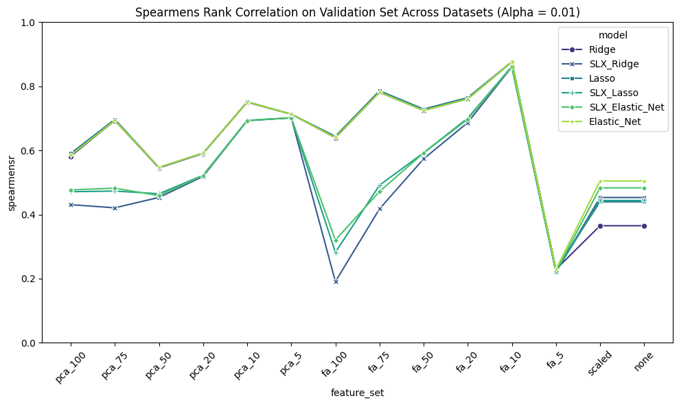

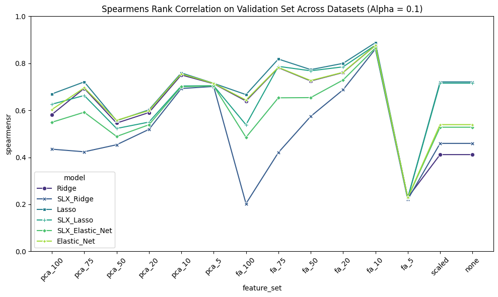

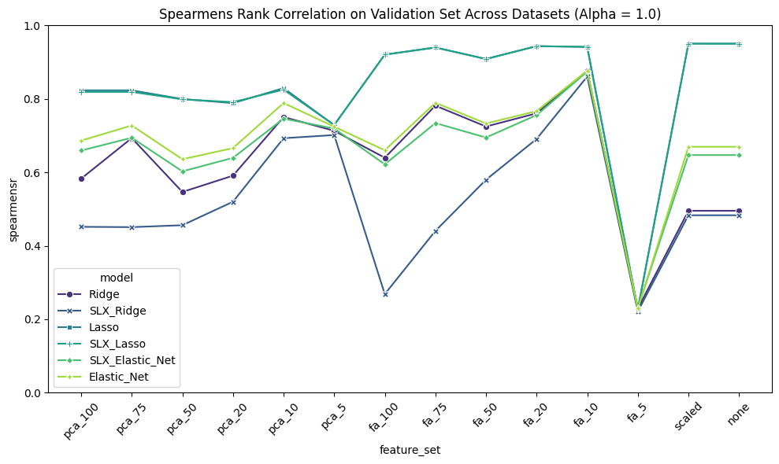

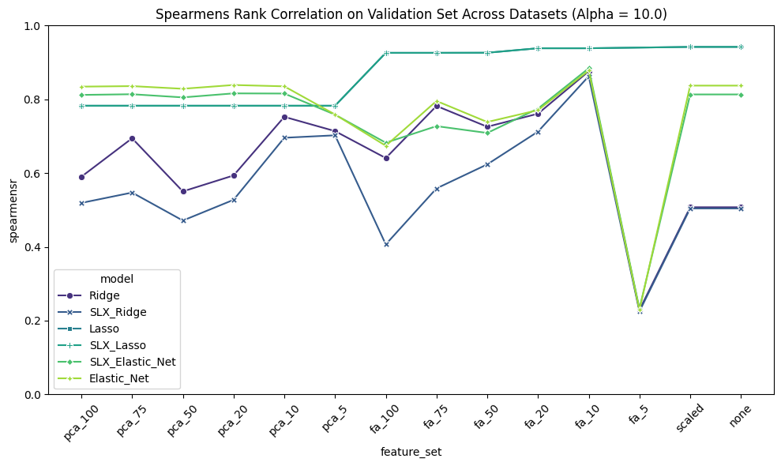

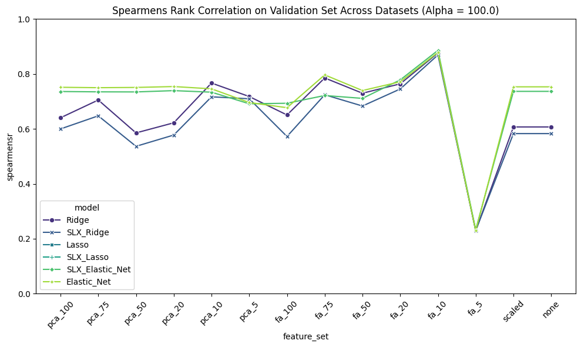

```python
alpha_values = results_df['alpha'].unique()

for alpha_val in alpha_values:
    plt.figure(figsize=(10, 6))

    subset = results_df[results_df['alpha'] == alpha_val]

    sns.lineplot(
        data=subset,
        x='feature_set',
        y='spearmensr',
        hue='model',
        style='model',
        markers=True,
        dashes=False,
        errorbar=None,
        palette="viridis"
    )

    plt.xticks(rotation=45)
    plt.title(f'Spearmens Rank Correlation on Validation Set Across Datasets (Alpha = {alpha_val})')
    plt.tight_layout()
    plt.ylim(0, 1)

    plt.show()
```

#### CV R Squared Scores

##### Mean

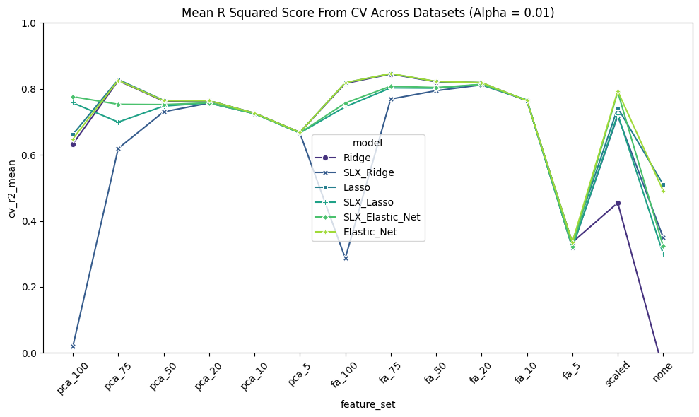

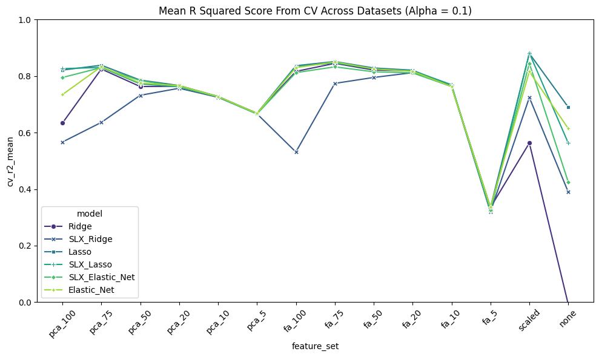

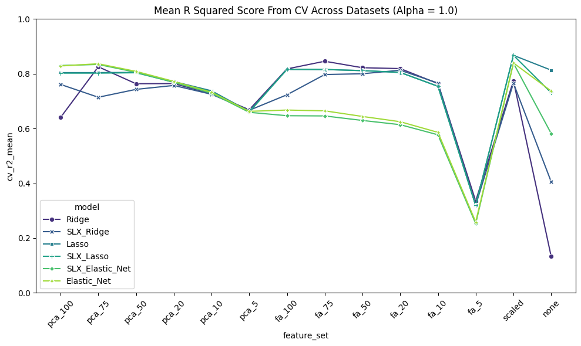

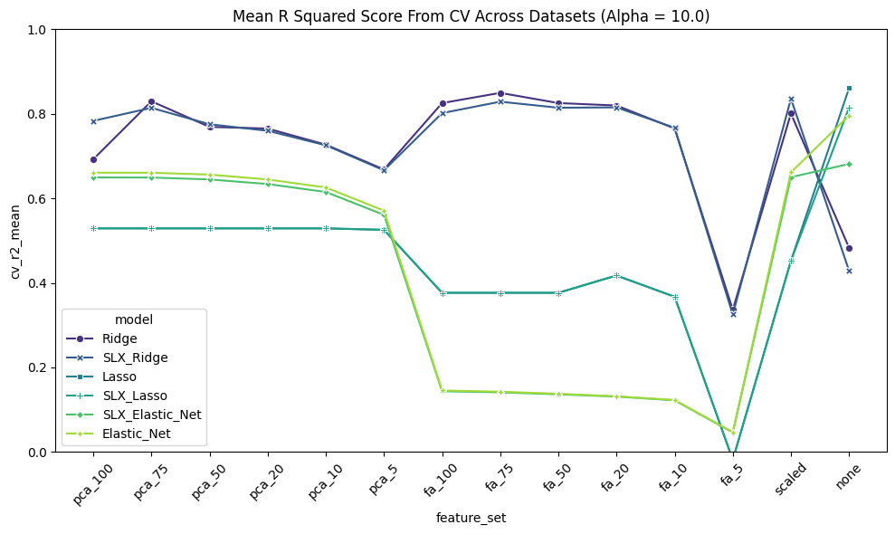

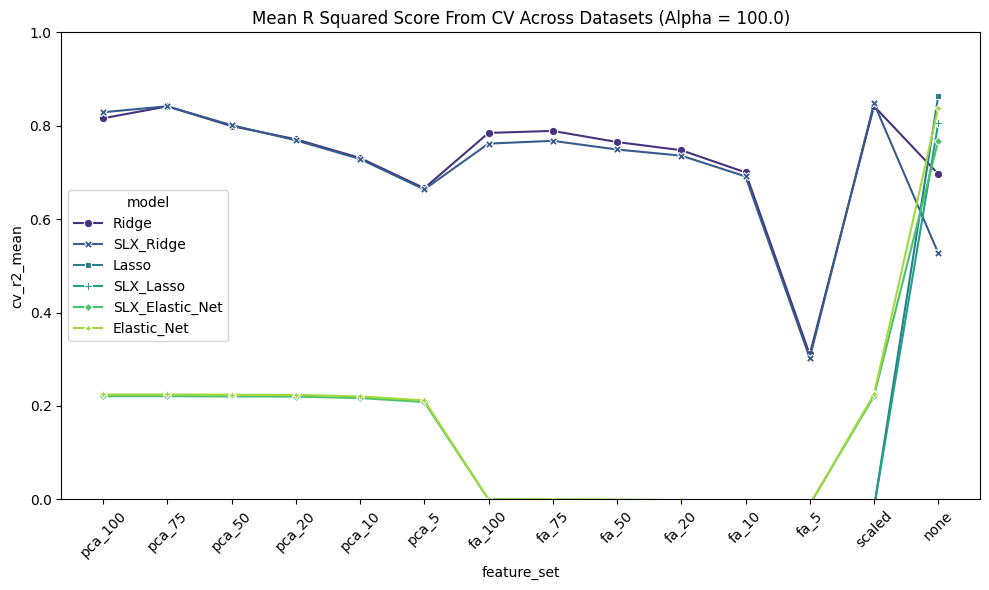

```python
alpha_values = results_df['alpha'].unique()

for alpha_val in alpha_values:
    plt.figure(figsize=(10, 6))

    subset = results_df[results_df['alpha'] == alpha_val]

    sns.lineplot(
        data=subset,
        x='feature_set',
        y='cv_r2_mean',
        hue='model',
        style='model',
        markers=True,
        dashes=False,
        errorbar=None,
        palette="viridis"
    )

    plt.xticks(rotation=45)
    plt.title(f'Mean R Squared Score From CV Across Datasets (Alpha = {alpha_val})')
    plt.tight_layout()
    plt.ylim(0, 1)

    plt.show()
```

Here similar patterns are observed at first to spearmens rank, but as regularisation strength is increased, Lasso and Elastic Net fall apart. This could be from all coefficients being shrunk to zero. Otherwise, models seem to hover around 0.8 for feature sets with high component count which is a good score.

##### Spread

Spread was observed to be an issue in a previous notebook focusing on showcasing the viability of an SLX model, as such it is an important comparison point.

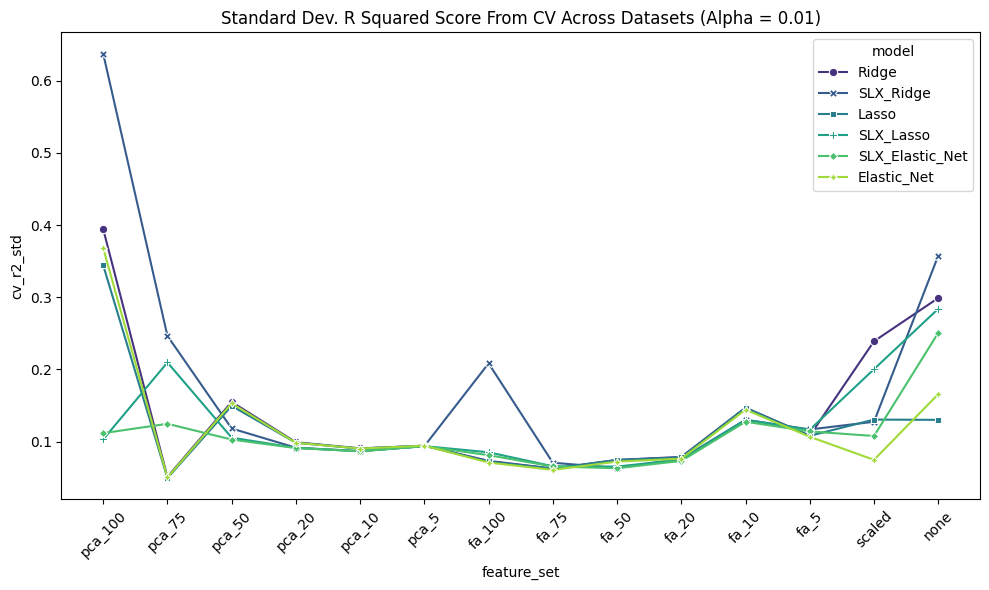

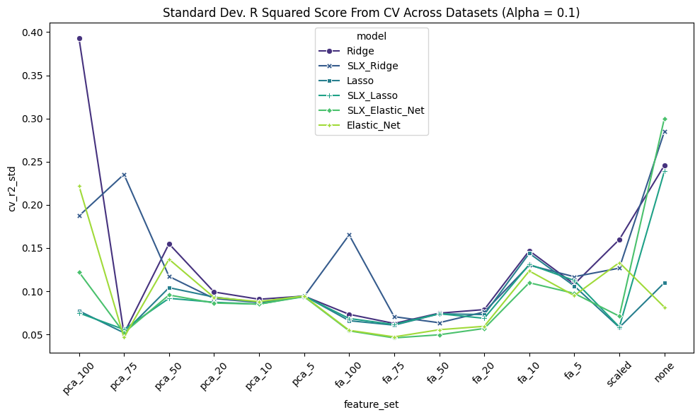

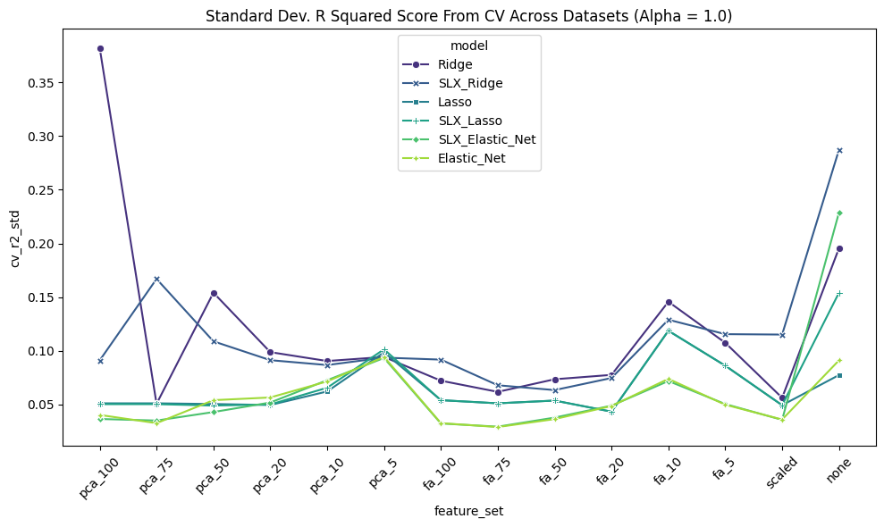

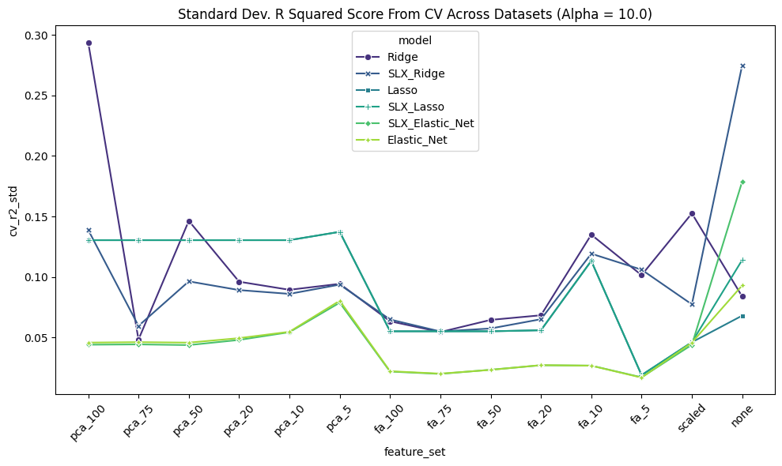

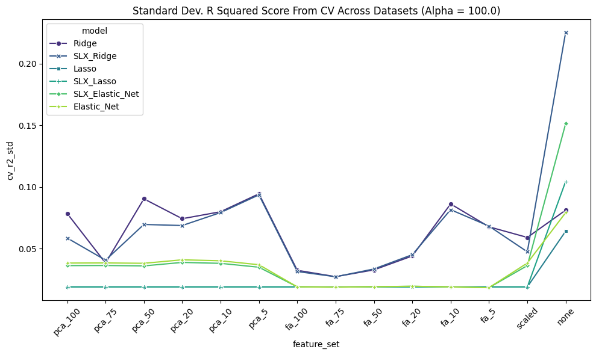

```python
alpha_values = results_df['alpha'].unique()

for alpha_val in alpha_values:
    plt.figure(figsize=(10, 6))

    subset = results_df[results_df['alpha'] == alpha_val]

    sns.lineplot(
        data=subset,
        x='feature_set',
        y='cv_r2_std',
        hue='model',
        style='model',
        markers=True,
        dashes=False,
        errorbar=None,
        palette="viridis"
    )

    plt.xticks(rotation=45)
    plt.title(f'Standard Dev. R Squared Score From CV Across Datasets (Alpha = {alpha_val})')
    plt.tight_layout()

    plt.show()
```

Again, Lasso seems to consistently outperform Ridge - though scores on high alpha values come from all values being null so are misleading. On these high alpha values however, Ridge models do achieve less than 0.05 standard deviation which is only really approached by Elastic Net on low alpha values where it had been seen to do well in other metrics too. Otherwise, spread from Lasso on low alpha values is comparable.

### Model Selection

Following initial exploration of model metrics, top performing models are selected next using multiple metrics.

```python
def pareto_front(df, cols):
    data = df[cols].values
    is_pareto = np.ones(data.shape[0], dtype=bool)

    for i, point in enumerate(data):
        if is_pareto[i]:
            is_pareto[is_pareto] = np.any(
                data[is_pareto] > point, axis=1
            ) | np.all(
                data[is_pareto] == point, axis=1
            )
            is_pareto[i] = True

    return df[is_pareto]

pareto_df = pareto_front(
    results_df,
    ['spearmensr', 'cv_r2_mean']
)
```

```python
pareto_df
```

|  | feature_set | model | cv_rmse_std | cv_rmse_mean | cv_r2_std | cv_r2_mean | cv_spearmensr_std | cv_spearmensr_mean | val_r2 | spearmensr | alpha | lr_ratio | direction |
| --- | --- | --- | --- | --- | --- | --- | --- | --- | --- | --- | --- | --- | --- |
| 372 | scaled | Lasso | 1.553187 | 6.249293 | 0.065353 | 0.846951 | 0.014203 | 0.943354 | 0.702618 | 0.959504 | 1.0 | 0 | 2019 -> 2025 |
| 376 | scaled | SLX_Lasso | 1.906692 | 5.936801 | 0.096680 | 0.854443 | 0.009075 | 0.942621 | 0.605887 | 0.951765 | 0.1 | 0 | 2019 -> 2025 |
| 377 | scaled | SLX_Lasso | 1.553187 | 6.249293 | 0.065353 | 0.846951 | 0.014203 | 0.943354 | 0.702618 | 0.959504 | 1.0 | 0 | 2019 -> 2025 |
| 791 | scaled | Lasso | 0.459823 | 4.733439 | 0.021605 | 0.907301 | 0.013528 | 0.950496 | -2.147244 | 0.492141 | 0.1 | 0 | 2025 -> 2019 |
| 796 | scaled | SLX_Lasso | 0.465009 | 4.714234 | 0.020605 | 0.908261 | 0.012562 | 0.950801 | -1.847608 | 0.479129 | 0.1 | 0 | 2025 -> 2019 |
| 797 | scaled | SLX_Lasso | 0.278563 | 5.183360 | 0.033513 | 0.887466 | 0.015917 | 0.949202 | 0.768401 | 0.941226 | 1.0 | 0 | 2025 -> 2019 |
| 823 | none | Lasso | 0.694170 | 5.284380 | 0.038613 | 0.881867 | 0.017977 | 0.954215 | 0.392083 | 0.937703 | 10.0 | 0 | 2025 -> 2019 |

### Coeff Analysis

As mentioned before, the high and close performance of SLX Lasso and Standard Lasso regression models should bear investigating coefficient shrinkage.

```python
# Merge with coefs_df to get coefficients for these top 3
top_coefs = coefs_df.reset_index().merge(
    pareto_df[['model', 'alpha', 'feature_set', 'direction']],
    on=['model', 'alpha', 'feature_set', 'direction'],
    how='inner'
)

top_coefs['model_id'] = (
    top_coefs[['model','alpha','feature_set','direction']]
    .astype(str)
    .agg('_'.join, axis=1)
)

top_coefs.sort_values(by='validation_value')
```

|  | feature_name | validation_value | cv_mean | cv_spread | model | alpha | feature_set | direction | model_id |
| --- | --- | --- | --- | --- | --- | --- | --- | --- | --- |
| 2164 | working_age_population | -3.064449 | -2.978045 | 0.264560 | SLX_Lasso | 0.1 | scaled | 2025 -> 2019 | SLX_Lasso_0.1_scaled_2025 -> 2019 |
| 1825 | working_age_population | -3.031401 | -3.004120 | 0.255376 | Lasso | 0.1 | scaled | 2025 -> 2019 | Lasso_0.1_scaled_2025 -> 2019 |
| 469 | working_age_population | -3.029147 | -3.147512 | 0.220520 | SLX_Lasso | 0.1 | scaled | 2019 -> 2025 | SLX_Lasso_0.1_scaled_2019 -> 2025 |
| 461 | landuse_greenfield_0 | -2.731005 | -2.366109 | 1.202224 | SLX_Lasso | 0.1 | scaled | 2019 -> 2025 | SLX_Lasso_0.1_scaled_2019 -> 2025 |
| 522 | pension_age_population | -2.137486 | -2.140452 | 0.156021 | SLX_Lasso | 0.1 | scaled | 2019 -> 2025 | SLX_Lasso_0.1_scaled_2019 -> 2025 |
| ... | ... | ... | ... | ... | ... | ... | ... | ... | ... |
| 1857 | mean_monthly_nwr_claims | 11.534761 | 11.781883 | 1.927633 | Lasso | 0.1 | scaled | 2025 -> 2019 | Lasso_0.1_scaled_2025 -> 2019 |
| 2874 | mean_monthly_nwr_claims | 13.132974 | 12.308627 | 1.203108 | SLX_Lasso | 1.0 | scaled | 2025 -> 2019 | SLX_Lasso_1.0_scaled_2025 -> 2019 |
| 1179 | mean_monthly_nwr_claims | 13.390375 | 13.237597 | 0.776729 | SLX_Lasso | 1.0 | scaled | 2019 -> 2025 | SLX_Lasso_1.0_scaled_2019 -> 2025 |
| 162 | mean_monthly_nwr_claims | 13.390375 | 13.237597 | 0.776729 | Lasso | 1.0 | scaled | 2019 -> 2025 | Lasso_1.0_scaled_2019 -> 2025 |
| 501 | mean_monthly_nwr_claims | 14.475963 | 13.837292 | 0.684588 | SLX_Lasso | 0.1 | scaled | 2019 -> 2025 | SLX_Lasso_0.1_scaled_2019 -> 2025 |

3729 rows × 9 columns

[output not shown]

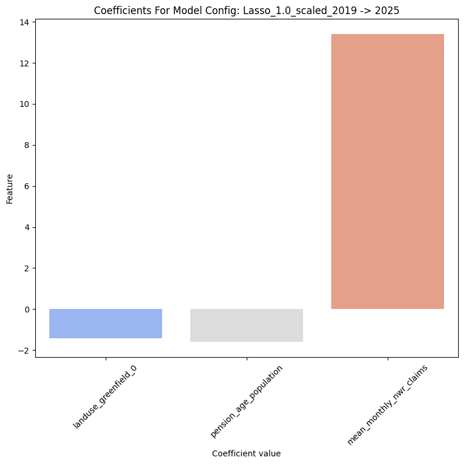

[output not shown]

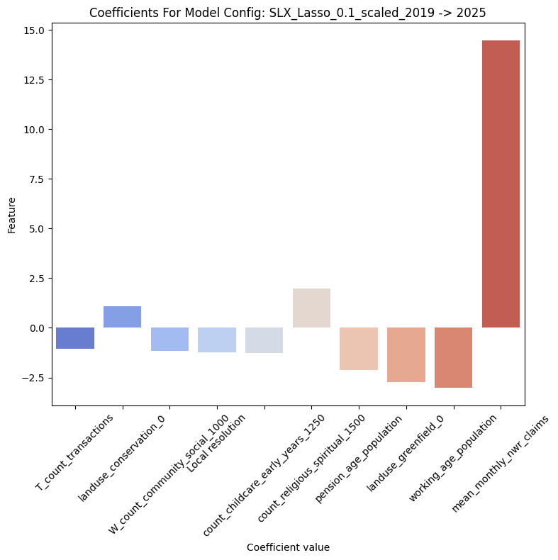

[output not shown]

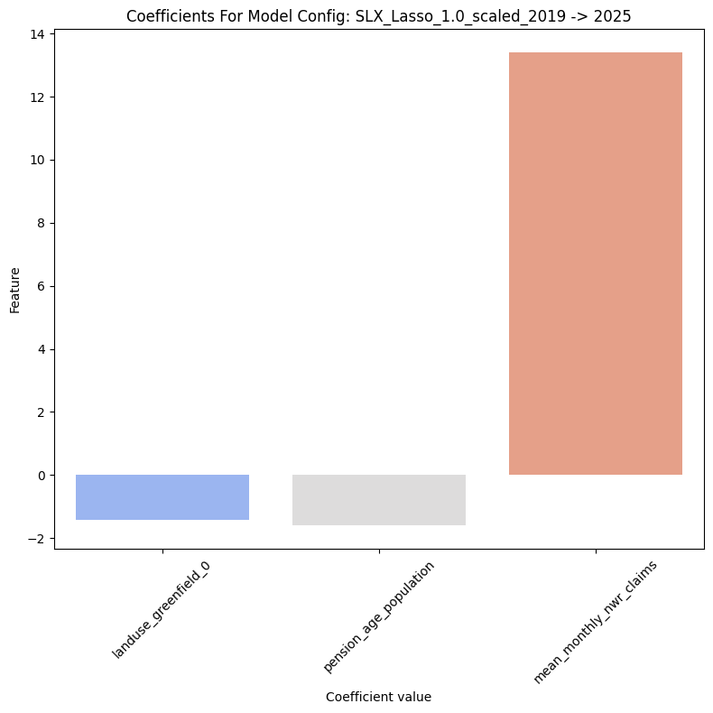

[output not shown]

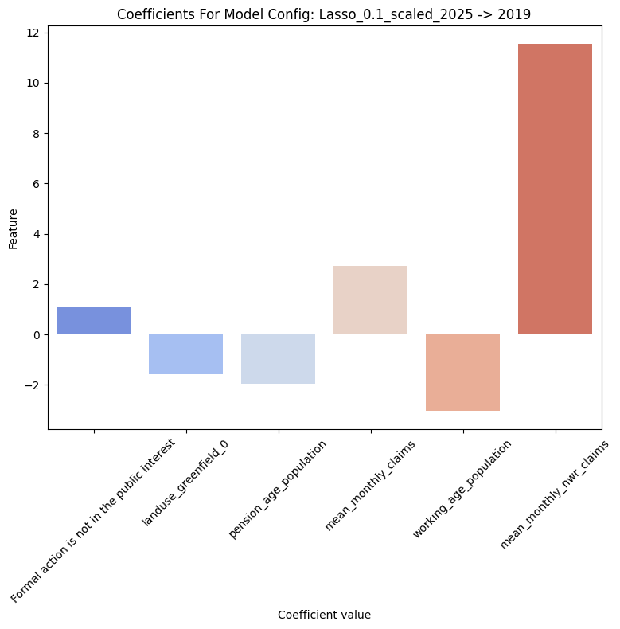

[output not shown]

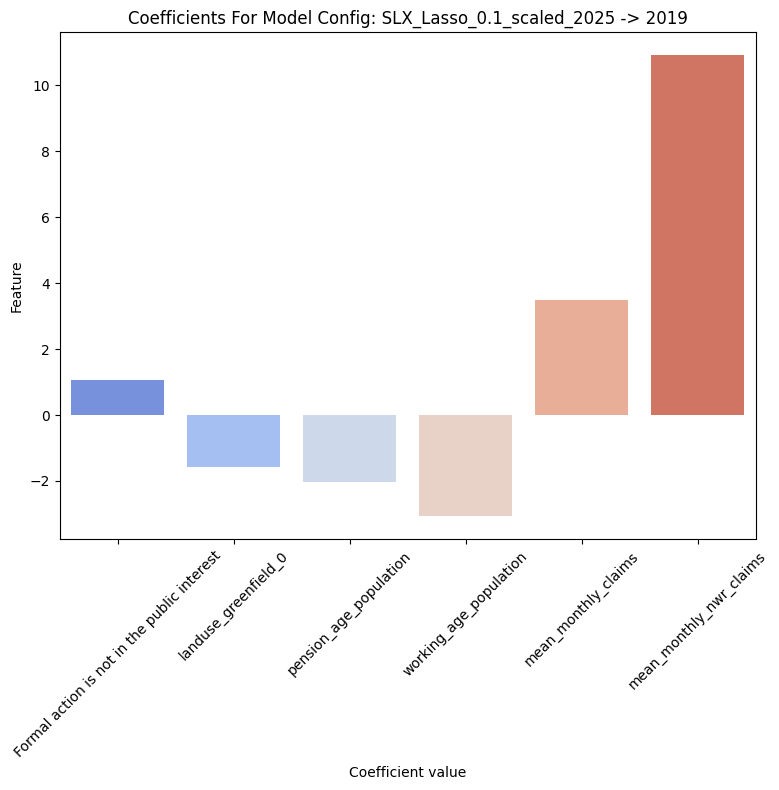

[output not shown]

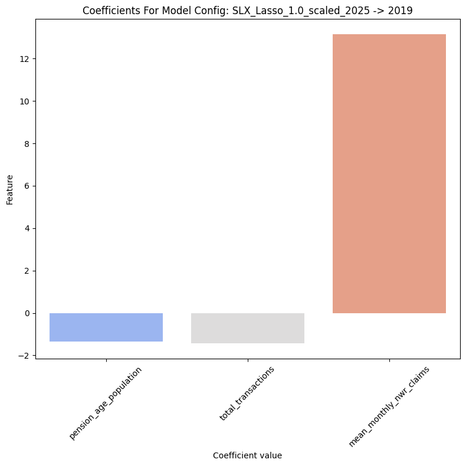

[output not shown]

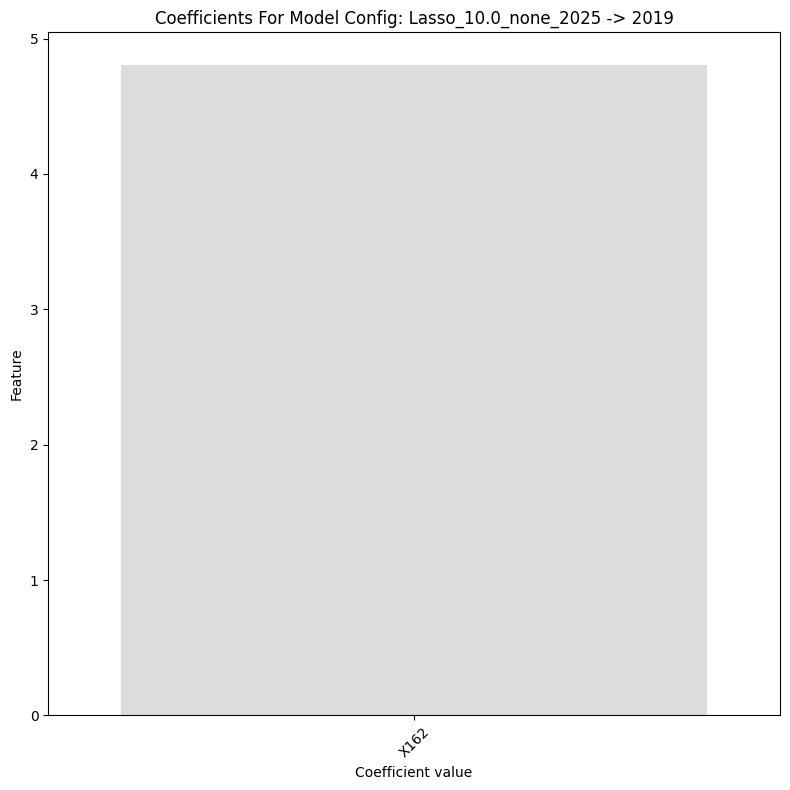

```python
# Loop through unique models
for model_id in top_coefs['model_id'].unique():
    subset = top_coefs[top_coefs['model_id'] == model_id].copy()

    # Sort features by validation coefficient magnitude
    subset['abs_val'] = subset['validation_value'].abs()
    subset = subset.sort_values('abs_val', ascending=True)

    subset = subset[subset['validation_value'].abs() >= 1]

    plt.figure(figsize=(8, 8))
    sns.barplot(
        x='feature_name',
        y='validation_value',
        data=subset,
        palette='coolwarm'
    )

    plt.title(f'Coefficients For Model Config: {model_id}', fontsize=12)
    plt.xlabel('Coefficient value')
    plt.xticks(rotation=45)
    plt.ylabel('Feature')
    plt.tight_layout()
    plt.show()
```

These coefficient plots are very revealing. Mean monthly 'no work requirements claims' for universal credit is consistently the most significant coefficient with a value usually above 10 whilst other coefficients absolute values don't even reach 5. Whatsmore, in all cases where the model is an SLX, spatial features are shrunk out apart from once on the number of community/social poi within 1 km which was with alpha at 0.1 (so on weaker regularisation).

Where does this leave us? Should prediction focus on utilising this dominant feature? How does this interact with previous fears of overfitting?

An assumption on how the model predicts from this could be that the dominant feature is enough to gauge the vague area where the deprivation score will sit and then the supporting features whose coefficients were relatively low offer correction and guidance to increase accuracy within the correct score area.

On the relevance of an SLX model, the lack of dominant "W" features is a bit dissapointing. An initial idea for why these are reduced out could be that the OSM features which aggregate within a boundary distance capture similar information. However, this is only the case for that dataset. The dominant UC feature does not have its spatial counterpart show up at all. Before concluding however, other modelling techniques coeffs should be explored too. Though Lasso models performed best, the highest scoring Ridge and Elastic Net were not too far behind.

(Note however that on these plots features whose absoloute coefficient value is less than 1 are hidden for interpretability)

### Coeff Analysis Without Lasso

```python
pareto_df = pareto_front(
    results_df.query("model != 'Lasso' and model != 'SLX_Lasso'"),
    ['spearmensr', 'cv_r2_mean']
)
```

```python
pareto_df
```

|  | feature_set | model | cv_rmse_std | cv_rmse_mean | cv_r2_std | cv_r2_mean | cv_spearmensr_std | cv_spearmensr_mean | val_r2 | spearmensr | alpha | lr_ratio | direction |
| --- | --- | --- | --- | --- | --- | --- | --- | --- | --- | --- | --- | --- | --- |
| 303 | fa_10 | Ridge | 1.480484 | 7.160779 | 0.094084 | 0.792429 | 0.018375 | 0.914324 | 0.520798 | 0.947047 | 10.0 | 0 | 2019 -> 2025 |
| 304 | fa_10 | Ridge | 0.890827 | 8.439101 | 0.042314 | 0.726054 | 0.018501 | 0.914310 | 0.540433 | 0.947082 | 100.0 | 0 | 2019 -> 2025 |
| 327 | fa_10 | Elastic_Net | 1.175807 | 10.133340 | 0.048448 | 0.607213 | 0.018501 | 0.914310 | 0.459685 | 0.947118 | 1.0 | 0 | 2019 -> 2025 |
| 364 | scaled | Ridge | 1.367948 | 6.377352 | 0.065152 | 0.839660 | 0.014980 | 0.931915 | -0.120963 | 0.920434 | 100.0 | 0 | 2019 -> 2025 |
| 381 | scaled | SLX_Elastic_Net | 1.545619 | 6.194037 | 0.076621 | 0.846412 | 0.013358 | 0.934544 | -0.678289 | 0.915833 | 0.1 | 0 | 2019 -> 2025 |
| 633 | fa_75 | Ridge | 0.232780 | 5.509552 | 0.034445 | 0.873055 | 0.024839 | 0.912513 | -0.484394 | 0.727286 | 10.0 | 0 | 2025 -> 2019 |
| 656 | fa_75 | Elastic_Net | 0.130283 | 5.549823 | 0.031803 | 0.871824 | 0.024973 | 0.912556 | -0.356465 | 0.727821 | 0.1 | 0 | 2025 -> 2019 |

```python
# Merge with coefs_df to get coefficients for these top 3
top_coefs = coefs_df.reset_index().merge(
    pareto_df[['model', 'alpha', 'feature_set', 'direction']],
    on=['model', 'alpha', 'feature_set', 'direction'],
    how='inner'
)

top_coefs['model_id'] = (
    top_coefs[['model','alpha','feature_set','direction']]
    .astype(str)
    .agg('_'.join, axis=1)
)

top_coefs.sort_values(by='validation_value')
```

|  | feature_name | validation_value | cv_mean | cv_spread | model | alpha | feature_set | direction | model_id |
| --- | --- | --- | --- | --- | --- | --- | --- | --- | --- |
| 1048 | FA_2 | -2.702710 | -2.620416 | 1.010634 | Ridge | 10.0 | fa_75 | 2025 -> 2019 | Ridge_10.0_fa_75_2025 -> 2019 |
| 1123 | FA_2 | -2.548688 | -2.493173 | 0.961447 | Elastic_Net | 0.1 | fa_75 | 2025 -> 2019 | Elastic_Net_0.1_fa_75_2025 -> 2019 |
| 1049 | FA_3 | -2.358285 | -2.101005 | 0.597829 | Ridge | 10.0 | fa_75 | 2025 -> 2019 | Ridge_10.0_fa_75_2025 -> 2019 |
| 1124 | FA_3 | -2.223892 | -1.999222 | 0.569129 | Elastic_Net | 0.1 | fa_75 | 2025 -> 2019 | Elastic_Net_0.1_fa_75_2025 -> 2019 |
| 491 | landuse_greenfield_0 | -2.036590 | -1.686058 | 0.869449 | SLX_Elastic_Net | 0.1 | scaled | 2019 -> 2025 | SLX_Elastic_Net_0.1_scaled_2019 -> 2025 |
| ... | ... | ... | ... | ... | ... | ... | ... | ... | ... |
| 20 | FA_1 | 7.284097 | 7.283712 | 0.251442 | Elastic_Net | 1.0 | fa_10 | 2019 -> 2025 | Elastic_Net_1.0_fa_10_2019 -> 2025 |
| 10 | FA_1 | 10.609445 | 9.932980 | 0.320597 | Ridge | 100.0 | fa_10 | 2019 -> 2025 | Ridge_100.0_fa_10_2019 -> 2025 |
| 1122 | FA_1 | 12.909773 | 12.909773 | 0.323772 | Elastic_Net | 0.1 | fa_75 | 2025 -> 2019 | Elastic_Net_0.1_fa_75_2025 -> 2019 |
| 1047 | FA_1 | 13.689932 | 13.567827 | 0.338916 | Ridge | 10.0 | fa_75 | 2025 -> 2019 | Ridge_10.0_fa_75_2025 -> 2019 |
| 0 | FA_1 | 14.044158 | 13.918031 | 0.475972 | Ridge | 10.0 | fa_10 | 2019 -> 2025 | Ridge_10.0_fa_10_2019 -> 2025 |

1197 rows × 9 columns

[output not shown]

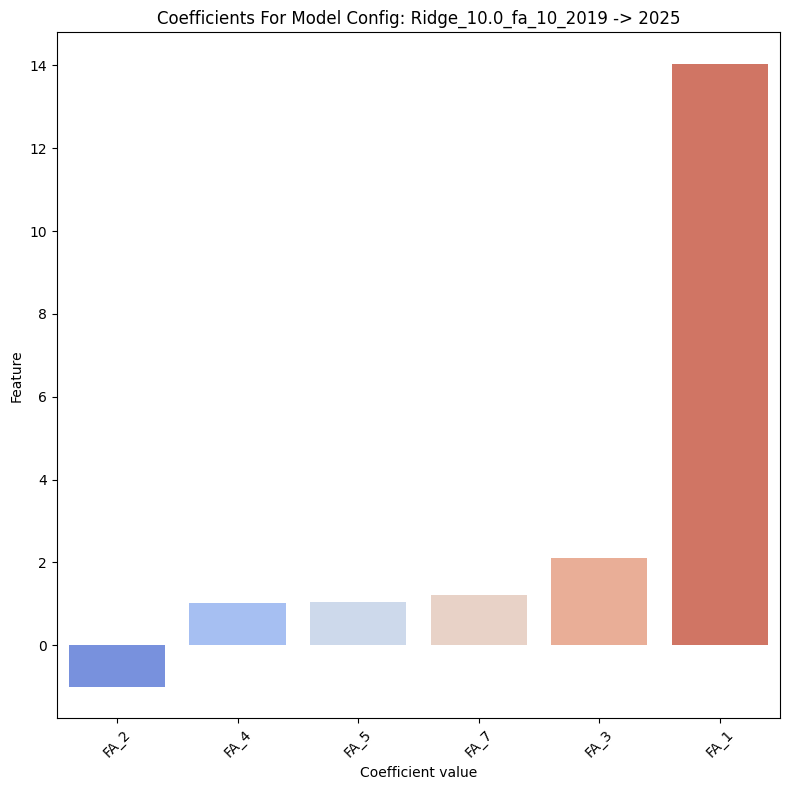

[output not shown]

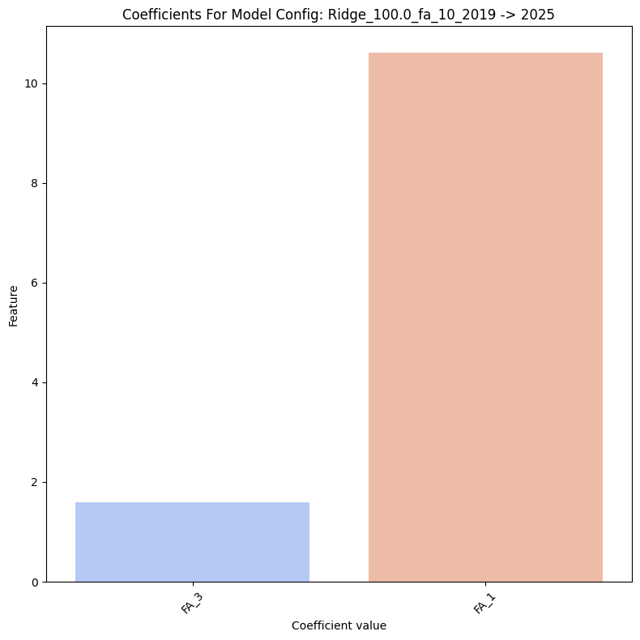

[output not shown]

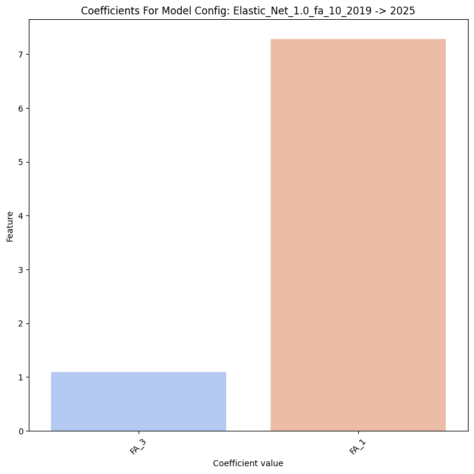

[output not shown]

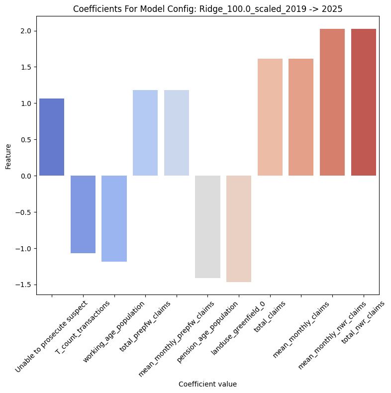

[output not shown]

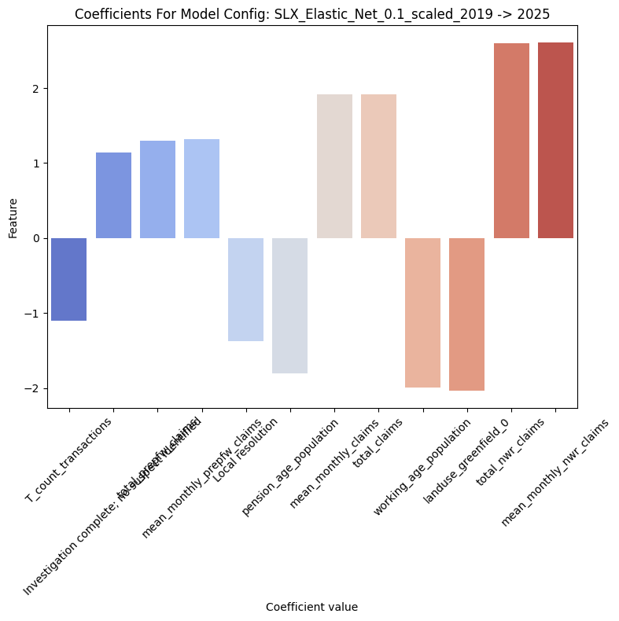

[output not shown]

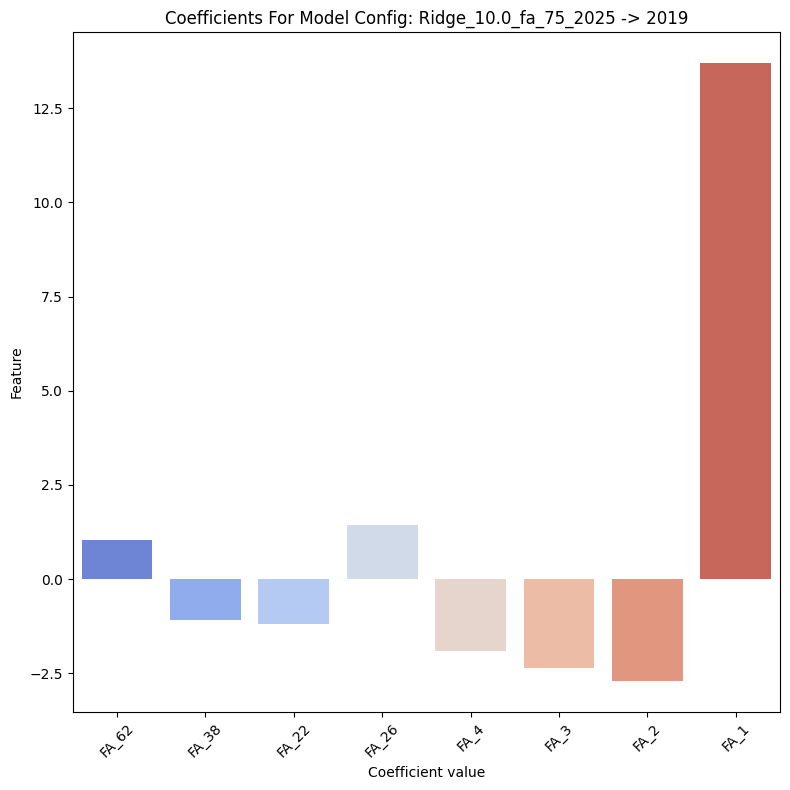

[output not shown]

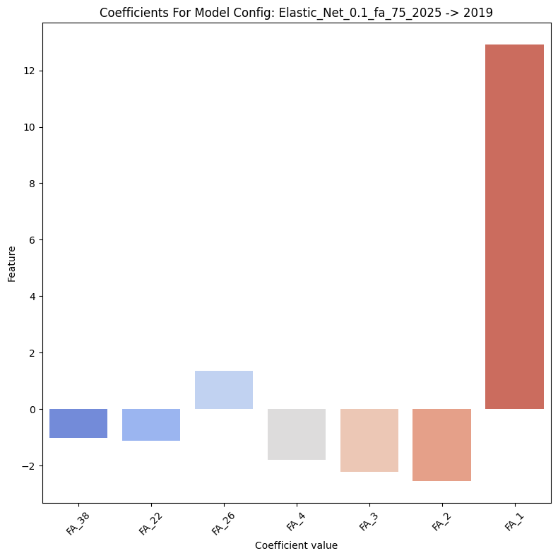

```python
# Loop through unique models
for model_id in top_coefs['model_id'].unique():
    subset = top_coefs[top_coefs['model_id'] == model_id].copy()

    # Sort features by validation coefficient magnitude
    subset['abs_val'] = subset['validation_value'].abs()
    subset = subset.sort_values('abs_val', ascending=True)

    subset = subset[subset['validation_value'].abs() >= 1]

    plt.figure(figsize=(8, 8))
    sns.barplot(
        x='feature_name',
        y='validation_value',
        data=subset,
        palette='coolwarm'
    )

    plt.title(f'Coefficients For Model Config: {model_id}', fontsize=12)
    plt.xlabel('Coefficient value')
    plt.xticks(rotation=45)
    plt.ylabel('Feature')
    plt.tight_layout()
    plt.show()
```

Here results are interesting again. Where FA was used, FA1 dominates in a fashion similar to coeff analysis on the Lasso models. It may be worth examining factor loadings to see if it holds the respective UC data.

On feature sets with just scaling, coefficient values are much more evenly spread than on Lasso. Though UC features are still the greatest in magnitude.

Only one SLX model was picked out here and it didn't select and spatial features.

Next this method is repeated once more except for this time focusing on SLX models specifically to see if spatial features are granted significant coefficients.

### Coeff Analysis On SLX

```python
pareto_df = pareto_front(
    results_df.query("model != 'Lasso' and model != 'SLX_Lasso' and model != 'Ridge' and model != 'Elastic_Net'"),
    ['spearmensr', 'cv_r2_mean']
)
```

```python
pareto_df
```

|  | feature_set | model | cv_rmse_std | cv_rmse_mean | cv_r2_std | cv_r2_mean | cv_spearmensr_std | cv_spearmensr_mean | val_r2 | spearmensr | alpha | lr_ratio | direction |
| --- | --- | --- | --- | --- | --- | --- | --- | --- | --- | --- | --- | --- | --- |
| 308 | fa_10 | SLX_Ridge | 1.349395 | 7.193072 | 0.085904 | 0.792027 | 0.020818 | 0.914841 | 0.503634 | 0.944195 | 10.0 | 0 | 2019 -> 2025 |
| 321 | fa_10 | SLX_Elastic_Net | 1.156650 | 7.294606 | 0.072659 | 0.788925 | 0.020665 | 0.914319 | 0.538451 | 0.945177 | 0.1 | 0 | 2019 -> 2025 |
| 369 | scaled | SLX_Ridge | 1.343315 | 6.399617 | 0.063476 | 0.838731 | 0.013553 | 0.932708 | -0.528907 | 0.920010 | 100.0 | 0 | 2019 -> 2025 |
| 381 | scaled | SLX_Elastic_Net | 1.545619 | 6.194037 | 0.076621 | 0.846412 | 0.013358 | 0.934544 | -0.678289 | 0.915833 | 0.1 | 0 | 2019 -> 2025 |
| 459 | pca_75 | SLX_Ridge | 0.577664 | 5.758056 | 0.020596 | 0.865632 | 0.024537 | 0.927984 | -0.762946 | 0.381244 | 100.0 | 0 | 2025 -> 2019 |
| 472 | pca_75 | SLX_Elastic_Net | 0.581166 | 5.952078 | 0.023485 | 0.856066 | 0.023822 | 0.930785 | 0.230730 | 0.472083 | 1.0 | 0 | 2025 -> 2019 |
| 651 | fa_75 | SLX_Elastic_Net | 0.259879 | 6.006329 | 0.034084 | 0.850383 | 0.030568 | 0.895531 | -23.761828 | 0.499760 | 0.1 | 0 | 2025 -> 2019 |

```python
# Merge with coefs_df to get coefficients for these top 3
top_coefs = coefs_df.reset_index().merge(
    pareto_df[['model', 'alpha', 'feature_set', 'direction']],
    on=['model', 'alpha', 'feature_set', 'direction'],
    how='inner'
)

top_coefs['model_id'] = (
    top_coefs[['model','alpha','feature_set','direction']]
    .astype(str)
    .agg('_'.join, axis=1)
)

top_coefs.sort_values(by='validation_value')
```

|  | feature_name | validation_value | cv_mean | cv_spread | model | alpha | feature_set | direction | model_id |
| --- | --- | --- | --- | --- | --- | --- | --- | --- | --- |
| 1697 | FA_2 | -2.260618 | -2.325806 | 0.965309 | SLX_Elastic_Net | 0.1 | fa_75 | 2025 -> 2019 | SLX_Elastic_Net_0.1_fa_75_2025 -> 2019 |
| 1698 | FA_3 | -2.100649 | -1.884182 | 0.552319 | SLX_Elastic_Net | 0.1 | fa_75 | 2025 -> 2019 | SLX_Elastic_Net_0.1_fa_75_2025 -> 2019 |
| 840 | landuse_greenfield_0 | -2.036590 | -1.686058 | 0.869449 | SLX_Elastic_Net | 0.1 | scaled | 2019 -> 2025 | SLX_Elastic_Net_0.1_scaled_2019 -> 2025 |
| 848 | working_age_population | -1.990387 | -1.907175 | 0.218126 | SLX_Elastic_Net | 0.1 | scaled | 2019 -> 2025 | SLX_Elastic_Net_0.1_scaled_2019 -> 2025 |
| 901 | pension_age_population | -1.805779 | -1.756263 | 0.149425 | SLX_Elastic_Net | 0.1 | scaled | 2019 -> 2025 | SLX_Elastic_Net_0.1_scaled_2019 -> 2025 |
| ... | ... | ... | ... | ... | ... | ... | ... | ... | ... |
| 1018 | total_nwr_claims | 2.600312 | 2.492887 | 0.077688 | SLX_Elastic_Net | 0.1 | scaled | 2019 -> 2025 | SLX_Elastic_Net_0.1_scaled_2019 -> 2025 |
| 880 | mean_monthly_nwr_claims | 2.604781 | 2.510674 | 0.078713 | SLX_Elastic_Net | 0.1 | scaled | 2019 -> 2025 | SLX_Elastic_Net_0.1_scaled_2019 -> 2025 |
| 1696 | FA_1 | 12.469327 | 12.311391 | 0.254642 | SLX_Elastic_Net | 0.1 | fa_75 | 2025 -> 2019 | SLX_Elastic_Net_0.1_fa_75_2025 -> 2019 |
| 20 | FA_1 | 13.035134 | 13.036320 | 0.366708 | SLX_Elastic_Net | 0.1 | fa_10 | 2019 -> 2025 | SLX_Elastic_Net_0.1_fa_10_2019 -> 2025 |
| 0 | FA_1 | 13.879253 | 13.746590 | 0.368632 | SLX_Ridge | 10.0 | fa_10 | 2019 -> 2025 | SLX_Ridge_10.0_fa_10_2019 -> 2025 |

1846 rows × 9 columns